# Survival-Final Version

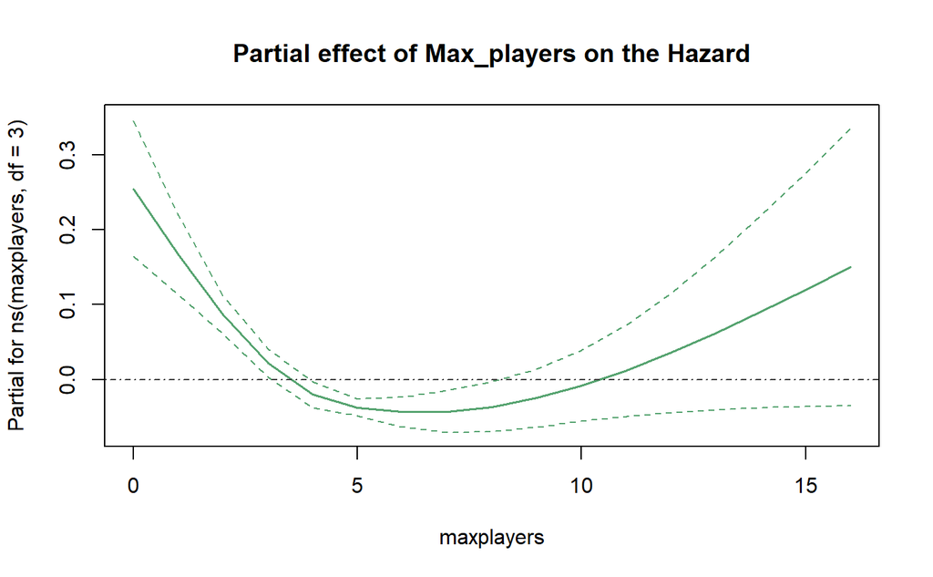

```r
termplot(mod.cox5, term=1, se=TRUE, col.term='#55A36F', col.se='#55A36F', main = 'Partial effect of Max_players on the Hazard')
abline(h = 0, lty = 4, col = "#3A3A3A")
```

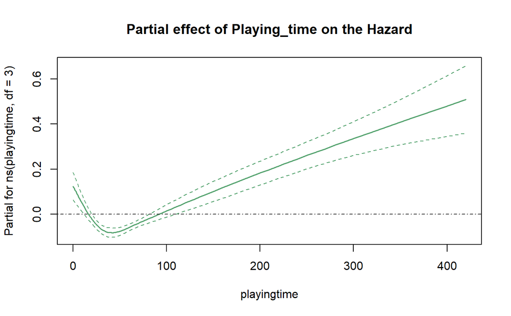

```r
termplot(mod.cox5, term=2, se=TRUE, col.term='#55A36F', col.se='#55A36F', main = 'Partial effect of Playing_time on the Hazard')
abline(h = 0, lty = 4, col = "#3A3A3A")
```

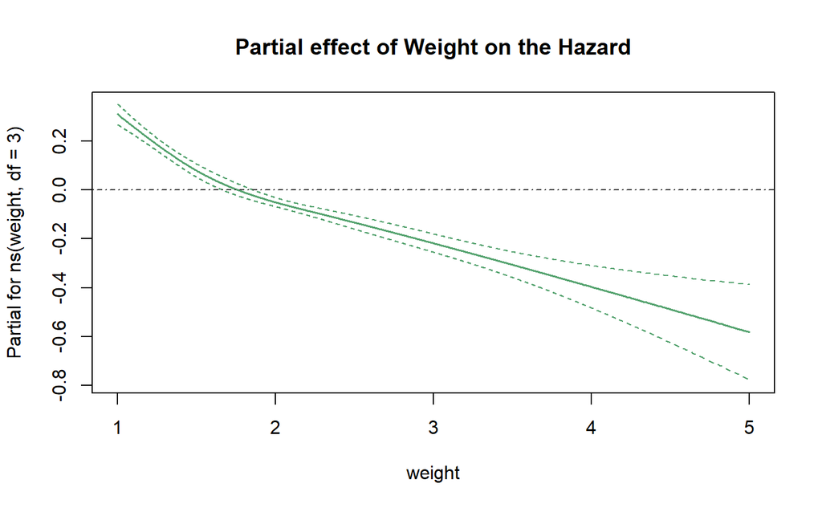

```r
termplot(mod.cox5, term=3, se=TRUE, col.term='#55A36F', col.se='#55A36F', main = 'Partial effect of Weight on the Hazard')
abline(h = 0, lty = 4, col = "#3A3A3A")
```

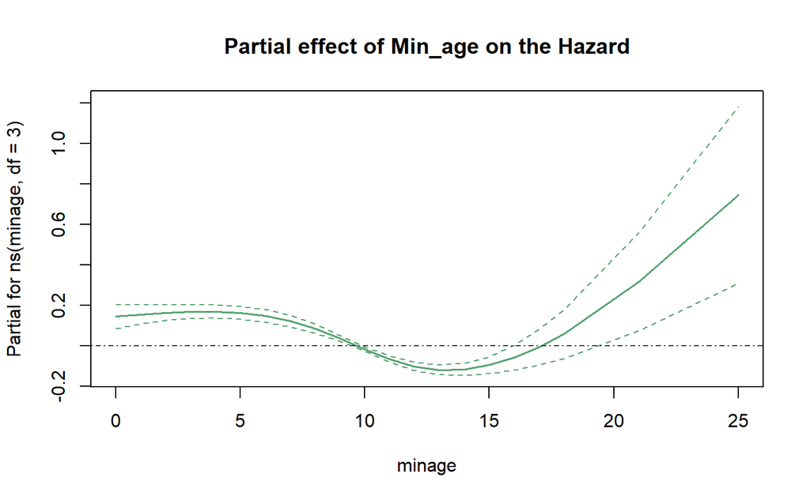

```r
termplot(mod.cox5, term=4, se=TRUE, col.term='#55A36F', col.se='#55A36F', main = 'Partial effect of Min_age on the Hazard')
abline(h = 0, lty = 4, col = "#3A3A3A")
```

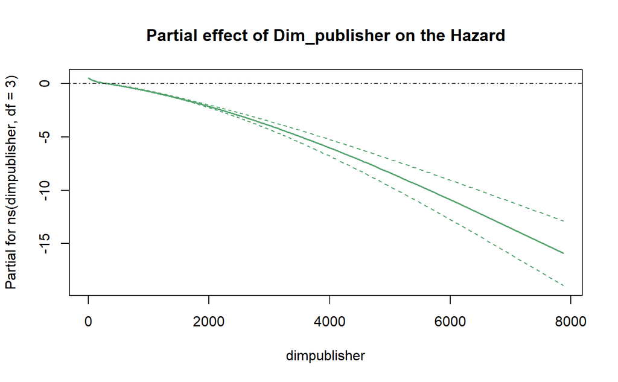

```r
termplot(mod.cox5, term=5, se=TRUE, col.term='#55A36F', col.se='#55A36F', main = 'Partial effect of Dim_publisher on the Hazard')
abline(h = 0, lty = 4, col = "#3A3A3A")
```

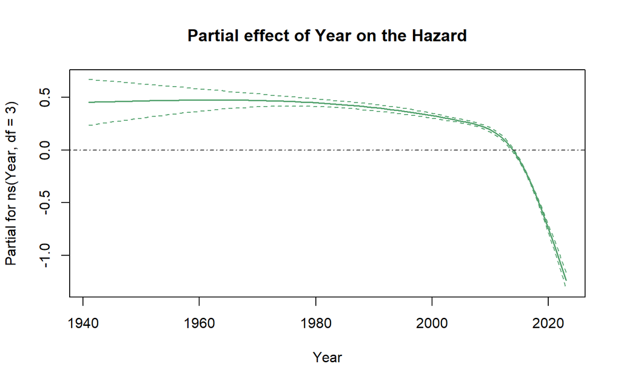

```r
termplot(mod.cox5, term=6, se=TRUE, col.term='#55A36F', col.se='#55A36F', main = 'Partial effect of Year on the Hazard')
abline(h = 0, lty = 4, col = "#3A3A3A")
```

```r
#All numerical variables (rcs spline)
mod.cox6=coxph(Surv(time, status) ~ rcs(maxplayers, df=5) + rcs(playingtime, df=5) + rcs(weight, df=5) + rcs(minage, df=5) + rcs(dimpublisher, df=5) + rcs(Year, df=5) , data = data)
```

```
number of knots in rcs defaulting to 5
number of knots in rcs defaulting to 5
number of knots in rcs defaulting to 5
number of knots in rcs defaulting to 5
number of knots in rcs defaulting to 5
number of knots in rcs defaulting to 5
```

```r
summary(mod.cox6)
```

```
Call:
coxph(formula = Surv(time, status) ~ rcs(maxplayers, df = 5) +
    rcs(playingtime, df = 5) + rcs(weight, df = 5) + rcs(minage,
    df = 5) + rcs(dimpublisher, df = 5) + rcs(Year, df = 5),
    data = data)

  n= 19936, number of events= 16715

                                               coef  exp(coef)   se(coef)       z Pr(>|z|)
rcs(maxplayers, df = 5)maxplayers        -7.418e-02  9.285e-01  1.316e-02  -5.637 1.73e-08 ***
rcs(maxplayers, df = 5)maxplayers'        1.139e-01  1.121e+00  4.294e-02   2.653 0.007978 **
rcs(maxplayers, df = 5)maxplayers''      -2.087e-01  8.116e-01  1.183e-01  -1.765 0.077611 .
rcs(playingtime, df = 5)playingtime      -7.013e-03  9.930e-01  1.651e-03  -4.248 2.16e-05 ***
rcs(playingtime, df = 5)playingtime'      2.015e-01  1.223e+00  7.658e-02   2.631 0.008508 **
rcs(playingtime, df = 5)playingtime''    -4.606e-01  6.309e-01  2.293e-01  -2.009 0.044537 *
rcs(playingtime, df = 5)playingtime'''    2.551e-01  1.291e+00  1.825e-01   1.398 0.162108
rcs(weight, df = 5)weight                -7.455e-01  4.745e-01  1.032e-01  -7.226 4.97e-13 ***
rcs(weight, df = 5)weight'                4.861e+00  1.291e+02  1.232e+00   3.944 8.01e-05 ***
rcs(weight, df = 5)weight''              -9.480e+00  7.633e-05  2.612e+00  -3.630 0.000284 ***
rcs(weight, df = 5)weight'''              6.447e+00  6.306e+02  2.191e+00   2.942 0.003262 **
rcs(minage, df = 5)minage                 2.533e-02  1.026e+00  9.207e-03   2.751 0.005944 **
rcs(minage, df = 5)minage'               -9.431e-02  9.100e-01  1.884e-02  -5.006 5.57e-07 ***
rcs(minage, df = 5)minage''               1.228e+00  3.415e+00  3.427e-01   3.584 0.000339 ***
rcs(minage, df = 5)minage'''             -1.959e+00  1.410e-01  7.888e-01  -2.483 0.013013 *
rcs(dimpublisher, df = 5)dimpublisher    -1.056e-02  9.895e-01  8.342e-04 -12.660  < 2e-16 ***
rcs(dimpublisher, df = 5)dimpublisher'    3.478e+00  3.241e+01  3.535e-01   9.841  < 2e-16 ***
rcs(dimpublisher, df = 5)dimpublisher''  -4.289e+00  1.372e-02  4.404e-01  -9.739  < 2e-16 ***
rcs(dimpublisher, df = 5)dimpublisher'''  8.278e-01  2.288e+00  9.097e-02   9.099  < 2e-16 ***
rcs(Year, df = 5)Year                    -3.550e-03  9.965e-01  1.758e-03  -2.019 0.043491 *
rcs(Year, df = 5)Year'                   -6.120e-03  9.939e-01  3.773e-03  -1.622 0.104772
rcs(Year, df = 5)Year''                  -2.792e-01  7.564e-01  7.651e-02  -3.650 0.000263 ***
rcs(Year, df = 5)Year'''                 -5.884e-01  5.552e-01  4.531e-01  -1.299 0.194003
---
Signif. codes:  0 ‘***’ 0.001 ‘**’ 0.01 ‘*’ 0.05 ‘.’ 0.1 ‘ ’ 1

                                         exp(coef) exp(-coef) lower .95 upper .95
rcs(maxplayers, df = 5)maxplayers        9.285e-01  1.077e+00 9.049e-01 9.528e-01
rcs(maxplayers, df = 5)maxplayers'       1.121e+00  8.923e-01 1.030e+00 1.219e+00
rcs(maxplayers, df = 5)maxplayers''      8.116e-01  1.232e+00 6.437e-01 1.023e+00
rcs(playingtime, df = 5)playingtime      9.930e-01  1.007e+00 9.898e-01 9.962e-01
```

[output cut: 9 more lines]

```
rcs(minage, df = 5)minage''              3.415e+00  2.928e-01 1.745e+00 6.684e+00
rcs(minage, df = 5)minage'''             1.410e-01  7.091e+00 3.005e-02 6.617e-01
rcs(dimpublisher, df = 5)dimpublisher    9.895e-01  1.011e+00 9.879e-01 9.911e-01
rcs(dimpublisher, df = 5)dimpublisher'   3.241e+01  3.086e-02 1.621e+01 6.479e+01
rcs(dimpublisher, df = 5)dimpublisher''  1.372e-02  7.289e+01 5.787e-03 3.252e-02
rcs(dimpublisher, df = 5)dimpublisher''' 2.288e+00  4.370e-01 1.915e+00 2.735e+00
rcs(Year, df = 5)Year                    9.965e-01  1.004e+00 9.930e-01 9.999e-01
rcs(Year, df = 5)Year'                   9.939e-01  1.006e+00 9.866e-01 1.001e+00
rcs(Year, df = 5)Year''                  7.564e-01  1.322e+00 6.510e-01 8.787e-01
rcs(Year, df = 5)Year'''                 5.552e-01  1.801e+00 2.285e-01 1.349e+00

Concordance= 0.663  (se = 0.002 )
Likelihood ratio test= 7381  on 23 df,   p=<2e-16
Wald test            = 5585  on 23 df,   p=<2e-16
Score (logrank) test = 6359  on 23 df,   p=<2e-16
```

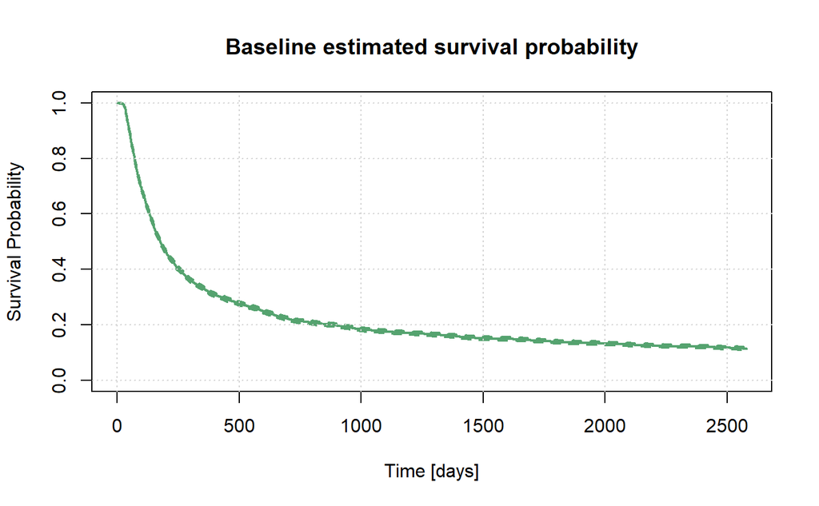

```r
#Plots:
#1)Hazard ratios:
#ggforest(mod.cox, data=data) #crystal clear ahahahah

#2)Baseline survival function:
plot(survfit(mod.cox6, data=data),
     col="#55A36F", lwd=2, lty=1,
     xlab='Time [days]', ylab='Survival Probability',
     main='Baseline estimated survival probability')
grid()
```

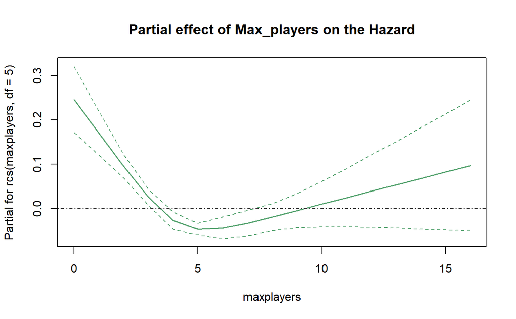

```r
termplot(mod.cox6, term=1, se=TRUE, col.term='#55A36F', col.se='#55A36F', main = 'Partial effect of Max_players on the Hazard')
abline(h = 0, lty = 4, col = "#3A3A3A")
```

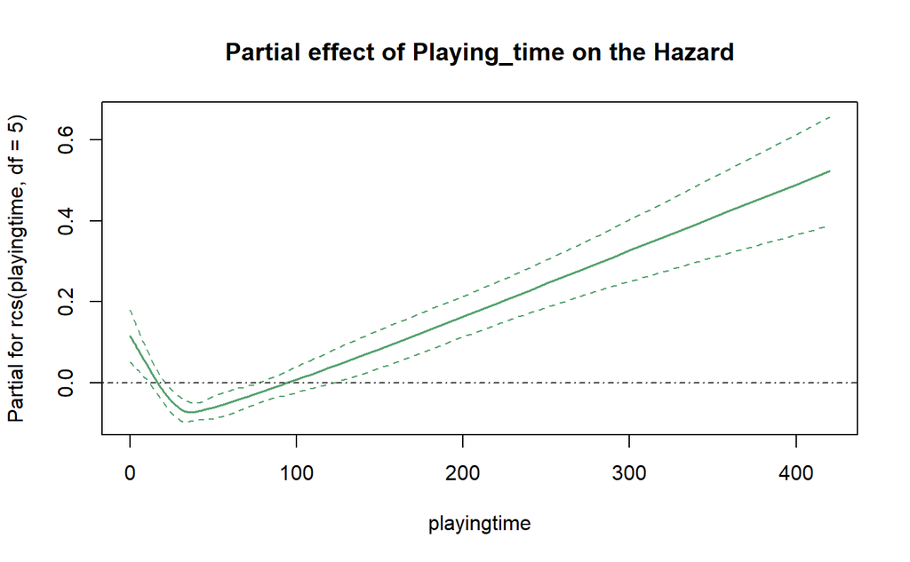

```r
termplot(mod.cox6, term=2, se=TRUE, col.term='#55A36F', col.se='#55A36F', main = 'Partial effect of Playing_time on the Hazard')
abline(h = 0, lty = 4, col = "#3A3A3A")
```

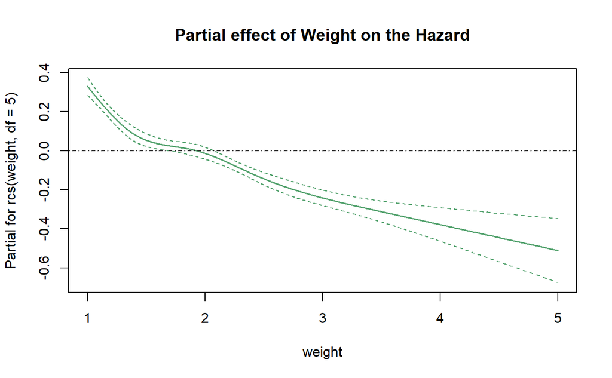

```r
termplot(mod.cox6, term=3, se=TRUE, col.term='#55A36F', col.se='#55A36F', main = 'Partial effect of Weight on the Hazard')
abline(h = 0, lty = 4, col = "#3A3A3A")
```

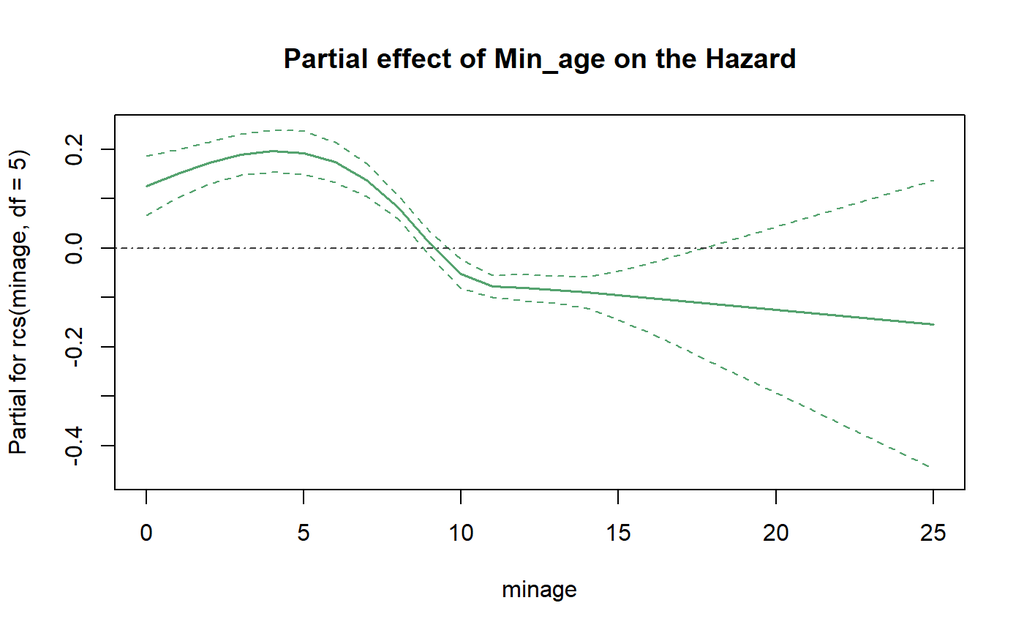

```r
termplot(mod.cox6, term=4, se=TRUE, col.term='#55A36F', col.se='#55A36F', main = 'Partial effect of Min_age on the Hazard')
abline(h = 0, lty = 4, col = "#3A3A3A")
```

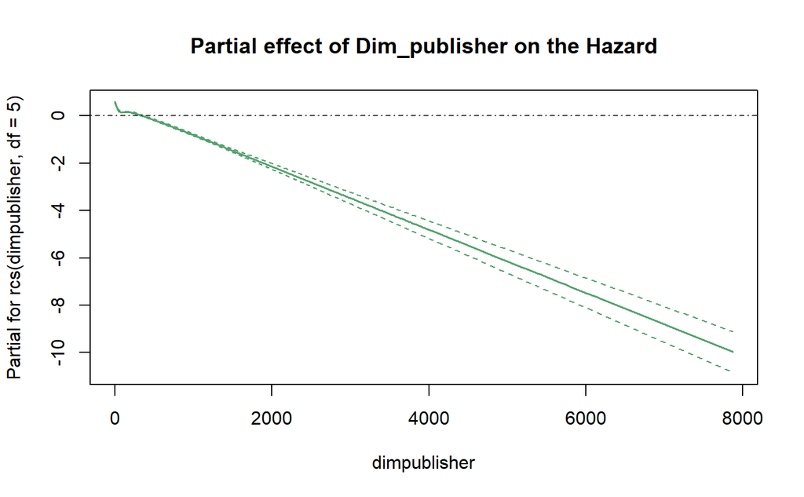

```r
termplot(mod.cox6, term=5, se=TRUE, col.term='#55A36F', col.se='#55A36F', main = 'Partial effect of Dim_publisher on the Hazard')
abline(h = 0, lty = 4, col = "#3A3A3A")
```

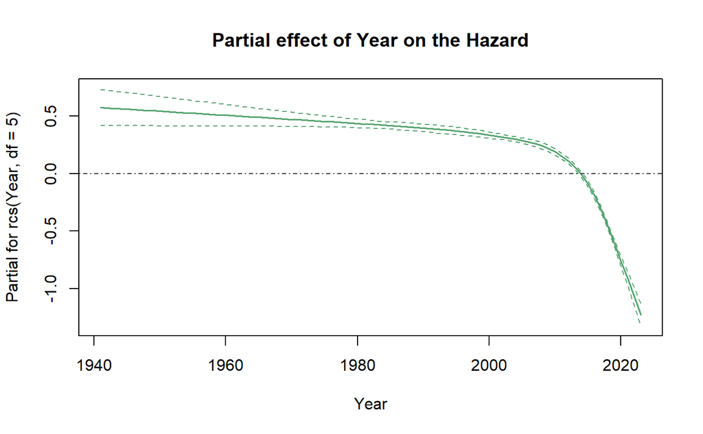

```r
termplot(mod.cox6, term=6, se=TRUE, col.term='#55A36F', col.se='#55A36F', main = 'Partial effect of Year on the Hazard')
abline(h = 0, lty = 4, col = "#3A3A3A")
```

## b) Categories

In this section we construct: a) a cox model for each category separately b) a cox model for all the categories together

##b) 1.A) Economic

As in section concerning KM estimator, we first show one category only (again the Economic one) and then we consider all the others

```r
#1.B)Economic
cox.economic <- coxph(Surv(time, status) ~ Economic_fact, data = data)
economic_df <- with(data, data.frame(Economic_fact = c("No", "Yes")))
fit.economic=survfit(cox.economic, newdata = economic_df)

#Plot:
plot(fit.economic, conf.int=T,
    col=c("#DE5A45","#2F6CA3"), lwd=2, lty=1,
    xlab='Time [days]', ylab='Survival Probability',
    main='Adjusted Survival Probability Plot for Economic vS Non-Economic groups')
grid()
```

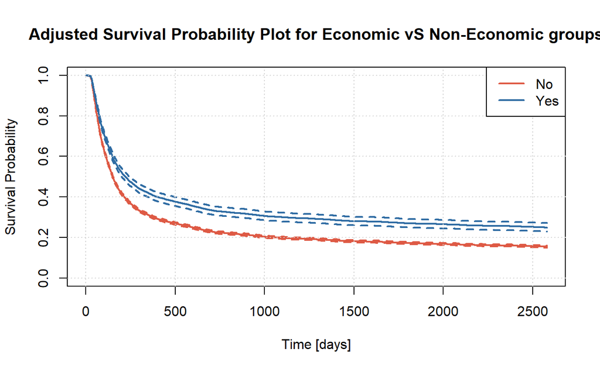

```r
legend('topright', c("No", "Yes"),
      lty=c(1,1), lwd=c(2,2), col=c("#DE5A45","#2F6CA3"))
```

##2.B) All categories (one-at-the-time)

```r
#2.B)All categories one-at-the-time:
data=data[, -c(105:188)]
columns_of_interest <- colnames(data)[17:100]
plot_list=list()
pdf("survival_final_cat_cox.pdf")
for (col in columns_of_interest) {
  data[[paste0(col, "_fact")]] = factor(data[[col]], labels = c('No', 'Yes'))
  covariate=data[,ncol(data)]
  cox<- coxph(Surv(time, status) ~ covariate, data = data)
  new_df <- with(data, data.frame(covariate = c("No", "Yes")))
  fit=survfit(cox, newdata = new_df)

  # Plot
  plot.new()
  plot=plot(fit, conf.int=T,
    col=c("#DE5A45","#2F6CA3"), lwd=2, lty=1,
    xlab='Time [days]', ylab='Survival Probability',
    main=paste("Adjusted Survival Probability Plot - ", col))
  legend('topright', c("No", "Yes"),
    lty=c(1,1), lwd=c(2,2), col=c("#DE5A45","#2F6CA3"))
  grid()
  plot_list[[col]] = plot
}

length(plot_list) #84

for (i in seq_along(plot_list)) {
  print(plot_list[[i]])
}
dev.off()
```

##3.B) All categories together

In the following box we consider a unique model containing all the categories together

```r
#3.C)All categories TOGETHER:
categories <- colnames(data[, 17:100])
formula <- as.formula(paste("Surv(time, status) ~", paste(categories, collapse = " + ")))
cox_categories <- coxph(formula, data = data)
```

```
Avvertimento: Loglik converged before variable  84 ; coefficient may be infinite.
```

```r
summary(cox_categories)
```

```
Call:
coxph(formula = formula, data = data)

  n= 19936, number of events= 16715

                                 coef  exp(coef)   se(coef)      z Pr(>|z|)
Economic                   -1.419e-01  8.677e-01  3.456e-02 -4.106 4.03e-05 ***
Negotiation                 8.033e-02  1.084e+00  4.846e-02  1.658 0.097359 .
Political                  -2.638e-01  7.681e-01  5.590e-02 -4.719 2.37e-06 ***
Card.Game                  -7.269e-02  9.299e-01  1.959e-02 -3.710 0.000207 ***
Fantasy                    -2.394e-01  7.871e-01  2.707e-02 -8.841  < 2e-16 ***
Abstract.Strategy           1.461e-01  1.157e+00  3.216e-02  4.543 5.54e-06 ***
Medieval                   -1.347e-01  8.739e-01  3.840e-02 -3.509 0.000449 ***
Ancient                    -1.401e-01  8.693e-01  4.625e-02 -3.029 0.002454 **
Territory.Building         -3.704e-01  6.904e-01  5.551e-02 -6.673 2.51e-11 ***
Civilization               -2.599e-01  7.711e-01  7.016e-02 -3.704 0.000212 ***
Nautical                   -1.293e-01  8.787e-01  4.817e-02 -2.684 0.007277 **
Children.s.Game             3.262e-01  1.386e+00  3.116e-02 10.468  < 2e-16 ***
City.Building              -5.195e-01  5.948e-01  5.739e-02 -9.052  < 2e-16 ***
Exploration                -2.161e-01  8.056e-01  4.447e-02 -4.861 1.17e-06 ***
Travel                     -2.114e-01  8.095e-01  7.781e-02 -2.717 0.006595 **
Farming                    -4.798e-01  6.189e-01  8.332e-02 -5.758 8.49e-09 ***
Mythology                  -1.386e-01  8.706e-01  6.367e-02 -2.176 0.029538 *
Bluffing                    8.948e-03  1.009e+00  3.737e-02  0.239 0.810766
Science.Fiction            -1.708e-01  8.430e-01  3.328e-02 -5.131 2.88e-07 ***
Collectible.Components      2.499e-01  1.284e+00  6.022e-02  4.151 3.32e-05 ***
Dice                       -7.674e-02  9.261e-01  2.885e-02 -2.660 0.007817 **
Fighting                   -9.878e-02  9.059e-01  3.299e-02 -2.994 0.002754 **
Print...Play                2.642e-01  1.302e+00  4.436e-02  5.956 2.59e-09 ***
Maze                        1.342e-01  1.144e+00  8.119e-02  1.653 0.098304 .
Miniatures                 -2.675e-01  7.653e-01  4.126e-02 -6.483 8.99e-11 ***
Racing                      1.529e-01  1.165e+00  4.636e-02  3.299 0.000971 ***
American.West              -8.605e-02  9.175e-01  7.524e-02 -1.144 0.252741
Wargame                     4.189e-01  1.520e+00  3.298e-02 12.701  < 2e-16 ***
Adventure                   2.981e-02  1.030e+00  3.903e-02  0.764 0.444984
Space.Exploration          -2.813e-01  7.548e-01  7.441e-02 -3.780 0.000157 ***
Renaissance                -3.299e-01  7.190e-01  7.518e-02 -4.388 1.14e-05 ***
Modern.Warfare             -1.271e-03  9.987e-01  6.425e-02 -0.020 0.984214
Humor                       1.045e-01  1.110e+00  3.549e-02  2.945 0.003235 **
Electronic                  8.143e-02  1.085e+00  7.842e-02  1.038 0.299107
```

[output cut: 128 more lines]

```
Arabian                    1.038e+00  9.629e-01  8.085e-01 1.334e+00
Pike.and.Shot              9.972e-01  1.003e+00  7.879e-01 1.262e+00
Educational                1.192e+00  8.388e-01  1.075e+00 1.323e+00
Religious                  9.427e-01  1.061e+00  7.709e-01 1.153e+00
Video.Game.Theme           9.406e-01  1.063e+00  8.330e-01 1.062e+00
Mature...Adult             1.242e+00  8.048e-01  1.031e+00 1.498e+00
Vietnam.War                8.660e-01  1.155e+00  6.566e-01 1.142e+00
Korean.War                 1.083e+00  9.237e-01  6.946e-01 1.687e+00
Expansion.for.Base.game    1.080e+00  9.258e-01  6.705e-01 1.740e+00
Fan.Expansion              4.616e-05  2.166e+04 3.458e-101 6.163e+91

Concordance= 0.593  (se = 0.002 )
Likelihood ratio test= 1942  on 84 df,   p=<2e-16
Wald test            = 1830  on 84 df,   p=<2e-16
Score (logrank) test = 1879  on 84 df,   p=<2e-16
```

```r
model.summary=summary(cox_categories)

covariates.categories.toremove <- names(which(model.summary$coefficients[, "Pr(>|z|)"] > 0.05))
covariates.categories.toremove
```

```
 [1] "Negotiation"                "Bluffing"                   "Maze"                       "American.West"
 [5] "Adventure"                  "Modern.Warfare"             "Electronic"                 "Word.Game"
 [9] "Aviation...Flight"          "Movies...TV...Radio.theme"  "Party.Game"                 "American.Civil.War"
[13] "Age.of.Reason"              "World.War.I"                "Trains"                     "Pirates"
[17] "Transportation"             "Action...Dexterity"         "Mafia"                      "Zombies"
[21] "Napoleonic"                 "Civil.War"                  "American.Indian.Wars"       "American.Revolutionary.War"
[25] "Math"                       "Music"                      "Arabian"                    "Pike.and.Shot"
[29] "Religious"                  "Video.Game.Theme"           "Vietnam.War"                "Korean.War"
[33] "Expansion.for.Base.game"    "Fan.Expansion"
```

```r
covariates.categories.reduced <- setdiff(colnames(data[,c(17:100)]),
                                         covariates.categories.toremove)

formula.1 <- as.formula(paste("Surv(time, status) ~", paste(covariates.categories.reduced, collapse = " + ")))
cox_categories <- coxph(formula.1, data = data)
summary(cox_categories)
```

```
Call:
coxph(formula = formula.1, data = data)

  n= 19936, number of events= 16715

                             coef exp(coef) se(coef)      z Pr(>|z|)
Economic                 -0.14547   0.86462  0.03349 -4.344 1.40e-05 ***
Political                -0.25644   0.77380  0.05406 -4.744 2.10e-06 ***
Card.Game                -0.07466   0.92806  0.01909 -3.910 9.21e-05 ***
Fantasy                  -0.22971   0.79477  0.02612 -8.795  < 2e-16 ***
Abstract.Strategy         0.14978   1.16158  0.03141  4.768 1.86e-06 ***
Medieval                 -0.13199   0.87635  0.03778 -3.494 0.000477 ***
Ancient                  -0.13583   0.87299  0.04519 -3.006 0.002648 **
Territory.Building       -0.37313   0.68858  0.05541 -6.735 1.64e-11 ***
Civilization             -0.25857   0.77215  0.06996 -3.696 0.000219 ***
Nautical                 -0.12288   0.88437  0.04600 -2.671 0.007561 **
Children.s.Game           0.33654   1.40010  0.02989 11.260  < 2e-16 ***
City.Building            -0.52743   0.59012  0.05711 -9.235  < 2e-16 ***
Exploration              -0.20254   0.81665  0.04204 -4.818 1.45e-06 ***
Travel                   -0.22652   0.79731  0.07730 -2.931 0.003384 **
Farming                  -0.48331   0.61674  0.08314 -5.813 6.14e-09 ***
Mythology                -0.13918   0.87007  0.06359 -2.189 0.028610 *
Science.Fiction          -0.15698   0.85472  0.03209 -4.893 9.95e-07 ***
Collectible.Components    0.25766   1.29390  0.05984  4.305 1.67e-05 ***
Dice                     -0.07342   0.92921  0.02866 -2.562 0.010414 *
Fighting                 -0.10216   0.90289  0.03268 -3.126 0.001774 **
Print...Play              0.26168   1.29911  0.04428  5.909 3.44e-09 ***
Miniatures               -0.26185   0.76963  0.04092 -6.399 1.57e-10 ***
Racing                    0.15481   1.16744  0.04610  3.358 0.000786 ***
Wargame                   0.39851   1.48961  0.02659 14.985  < 2e-16 ***
Space.Exploration        -0.28505   0.75198  0.07427 -3.838 0.000124 ***
Renaissance              -0.32975   0.71911  0.07392 -4.461 8.16e-06 ***
Humor                     0.10709   1.11304  0.03438  3.115 0.001842 **
Horror                   -0.16585   0.84717  0.04679 -3.545 0.000393 ***
Novel.based              -0.15940   0.85265  0.05392 -2.956 0.003113 **
Deduction                -0.27003   0.76336  0.04042 -6.681 2.38e-11 ***
Memory                    0.25733   1.29347  0.04980  5.167 2.38e-07 ***
Puzzle                   -0.36374   0.69507  0.04827 -7.535 4.89e-14 ***
Real.time                -0.16920   0.84434  0.04439 -3.812 0.000138 ***
Trivia                    0.26739   1.30655  0.04996  5.353 8.67e-08 ***
```

[output cut: 60 more lines]

```
Game.System                 1.6148     0.6193    1.0712    2.4343
Number                      0.8385     1.1926    0.7140    0.9847
Spies.Secret.Agents         0.7454     1.3416    0.6315    0.8798
Medical                     0.6586     1.5183    0.5073    0.8550
Comic.Book...Strip          0.8450     1.1834    0.7465    0.9566
Post.Napoleonic             0.8284     1.2072    0.7169    0.9573
Book                        1.4540     0.6878    1.2338    1.7134
Environmental               0.6761     1.4791    0.5615    0.8140
Educational                 1.1984     0.8345    1.0815    1.3279
Mature...Adult              1.2432     0.8044    1.0322    1.4972

Concordance= 0.592  (se = 0.002 )
Likelihood ratio test= 1892  on 50 df,   p=<2e-16
Wald test            = 1786  on 50 df,   p=<2e-16
Score (logrank) test = 1828  on 50 df,   p=<2e-16
```

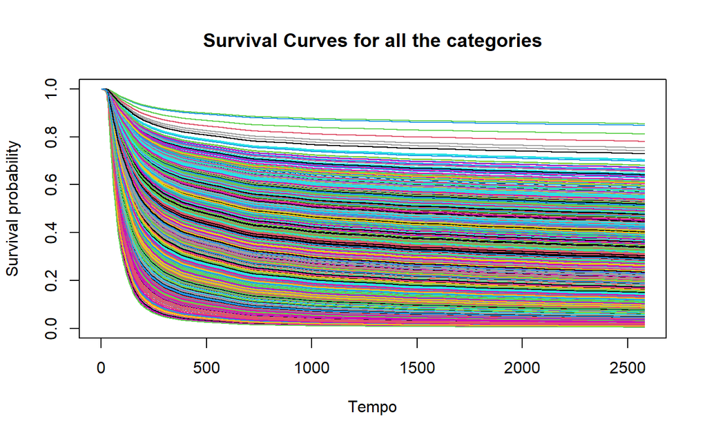

```r
new_data <- data[covariates.categories.reduced]
surv_fit <- survfit(cox_categories, newdata = new_data)

plot(surv_fit, col = 1:84, lty = 1, xlab = 'Tempo', ylab = 'Survival probability', main = 'Survival Curves for all the categories')
```

###3) Complete model (continuous covariates + categories):

```r
categories <- colnames(data[, 17:100])
formula <- as.formula(paste("Surv(time, status) ~ bs(maxplayers, df=3) + bs(playingtime, df=3) + bs(weight, df=3) + bs(minage, df=3) + bs(dimpublisher, df=3) + bs(Year, df=3) + ", paste(categories, collapse = " + ")))
mod.cox7 <- coxph(formula, data = data)
```

```
Avvertimento: Loglik converged before variable  102 ; coefficient may be infinite.
```

```r
summary(mod.cox7)
```

```
Call:
coxph(formula = formula, data = data)

  n= 19936, number of events= 16715

                                 coef  exp(coef)   se(coef)       z Pr(>|z|)
bs(maxplayers, df = 3)1    -1.936e-01  8.240e-01  1.454e-01  -1.332 0.182979
bs(maxplayers, df = 3)2    -1.390e-01  8.702e-01  1.225e-01  -1.135 0.256355
bs(maxplayers, df = 3)3    -1.055e-02  9.895e-01  1.509e-01  -0.070 0.944246
bs(playingtime, df = 3)1   -4.846e-01  6.160e-01  1.138e-01  -4.258 2.07e-05 ***
bs(playingtime, df = 3)2    6.826e-01  1.979e+00  1.591e-01   4.289 1.79e-05 ***
bs(playingtime, df = 3)3   -1.601e-01  8.520e-01  1.471e-01  -1.089 0.276256
bs(weight, df = 3)1        -5.573e-01  5.728e-01  9.060e-02  -6.151 7.71e-10 ***
bs(weight, df = 3)2        -2.277e-01  7.964e-01  1.439e-01  -1.582 0.113599
bs(weight, df = 3)3        -8.386e-01  4.323e-01  1.842e-01  -4.553 5.30e-06 ***
bs(minage, df = 3)1         5.290e-01  1.697e+00  1.327e-01   3.986 6.71e-05 ***
bs(minage, df = 3)2        -1.551e+00  2.121e-01  2.423e-01  -6.400 1.56e-10 ***
bs(minage, df = 3)3         1.394e+00  4.032e+00  3.815e-01   3.655 0.000258 ***
bs(dimpublisher, df = 3)1  -3.792e+00  2.256e-02  2.280e-01 -16.627  < 2e-16 ***
bs(dimpublisher, df = 3)2  -1.719e+00  1.793e-01  1.967e+00  -0.874 0.382198
bs(dimpublisher, df = 3)3  -3.572e+01  3.066e-16  1.159e+01  -3.081 0.002060 **
bs(Year, df = 3)1          -3.423e+00  3.260e-02  3.270e-01 -10.468  < 2e-16 ***
bs(Year, df = 3)2           3.932e-01  1.482e+00  1.597e-01   2.462 0.013829 *
bs(Year, df = 3)3          -2.673e+00  6.903e-02  1.998e-01 -13.377  < 2e-16 ***
Economic                   -3.367e-02  9.669e-01  3.591e-02  -0.938 0.348473
Negotiation                 1.063e-01  1.112e+00  4.876e-02   2.179 0.029330 *
Political                  -2.056e-01  8.142e-01  5.628e-02  -3.652 0.000260 ***
Card.Game                  -8.335e-02  9.200e-01  2.035e-02  -4.096 4.20e-05 ***
Fantasy                    -6.522e-02  9.369e-01  2.759e-02  -2.364 0.018084 *
Abstract.Strategy           5.725e-03  1.006e+00  3.355e-02   0.171 0.864516
Medieval                   -2.299e-02  9.773e-01  3.857e-02  -0.596 0.551201
Ancient                    -5.218e-02  9.492e-01  4.645e-02  -1.123 0.261339
Territory.Building         -2.016e-01  8.174e-01  5.585e-02  -3.610 0.000306 ***
Civilization               -9.521e-02  9.092e-01  7.116e-02  -1.338 0.180884
Nautical                   -9.851e-02  9.062e-01  4.813e-02  -2.047 0.040686 *
Children.s.Game             1.356e-01  1.145e+00  3.451e-02   3.929 8.52e-05 ***
City.Building              -2.280e-01  7.962e-01  5.792e-02  -3.936 8.29e-05 ***
Exploration                -1.225e-01  8.847e-01  4.475e-02  -2.738 0.006186 **
Travel                     -8.477e-02  9.187e-01  7.819e-02  -1.084 0.278310
Farming                    -2.501e-01  7.787e-01  8.380e-02  -2.984 0.002842 **
```

[output cut: 164 more lines]

```
Arabian                    1.034e+00  9.675e-01  8.044e-01 1.328e+00
Pike.and.Shot              1.018e+00  9.823e-01  8.046e-01 1.288e+00
Educational                1.074e+00  9.308e-01  9.686e-01 1.192e+00
Religious                  8.954e-01  1.117e+00  7.325e-01 1.095e+00
Video.Game.Theme           9.947e-01  1.005e+00  8.805e-01 1.124e+00
Mature...Adult             1.066e+00  9.384e-01  8.638e-01 1.315e+00
Vietnam.War                9.021e-01  1.109e+00  6.848e-01 1.188e+00
Korean.War                 1.131e+00  8.839e-01  7.270e-01 1.761e+00
Expansion.for.Base.game    1.077e+00  9.285e-01  6.681e-01 1.736e+00
Fan.Expansion              4.260e-05  2.347e+04 8.884e-107 2.043e+97

Concordance= 0.664  (se = 0.002 )
Likelihood ratio test= 7461  on 102 df,   p=<2e-16
Wald test            = 5666  on 102 df,   p=<2e-16
Score (logrank) test = 6395  on 102 df,   p=<2e-16
```

```r
model.summary.final=summary(mod.cox7)

covariates.toremove <- names(which(model.summary.final$coefficients[c(19:nrow(model.summary.final$coefficients)), "Pr(>|z|)"] > 0.05))
covariates.toremove
```

```
 [1] "Economic"                   "Abstract.Strategy"          "Medieval"                   "Ancient"
 [5] "Civilization"               "Travel"                     "Mythology"                  "Bluffing"
 [9] "Science.Fiction"            "Collectible.Components"     "Print...Play"               "Maze"
[13] "Racing"                     "American.West"              "Adventure"                  "Space.Exploration"
[17] "Renaissance"                "Modern.Warfare"             "Humor"                      "Electronic"
[21] "Horror"                     "Novel.based"                "Deduction"                  "Word.Game"
[25] "Aviation...Flight"          "Movies...TV...Radio.theme"  "Party.Game"                 "Real.time"
[29] "Trivia"                     "World.War.II"               "American.Civil.War"         "Age.of.Reason"
[33] "World.War.I"                "Trains"                     "Pirates"                    "Murder.Mystery"
[37] "Prehistoric"                "Game.System"                "Number"                     "Medical"
[41] "Mafia"                      "Zombies"                    "Comic.Book...Strip"         "Napoleonic"
[45] "Civil.War"                  "Post.Napoleonic"            "American.Indian.Wars"       "American.Revolutionary.War"
[49] "Math"                       "Music"                      "Arabian"                    "Pike.and.Shot"
[53] "Educational"                "Religious"                  "Video.Game.Theme"           "Mature...Adult"
[57] "Vietnam.War"                "Korean.War"                 "Expansion.for.Base.game"    "Fan.Expansion"
```

```r
covariates.reduced <- setdiff(colnames(data[,c(17:100)]),
                                         covariates.toremove)

formula.2 <- as.formula(paste("Surv(time, status) ~ bs(weight, df=3) + bs(minage, df=3) + bs(dimpublisher, df=3) + bs(playingtime, df=3) + bs(Year, df=3) + ", paste(covariates.reduced, collapse = " + ")))
mod.cox8 <- coxph(formula.2, data = data)
summary(mod.cox8)
```

```
Call:
coxph(formula = formula.2, data = data)

  n= 19936, number of events= 16715

                                coef  exp(coef)   se(coef)       z Pr(>|z|)
bs(weight, df = 3)1       -5.763e-01  5.620e-01  8.749e-02  -6.587 4.48e-11 ***
bs(weight, df = 3)2       -2.895e-01  7.486e-01  1.417e-01  -2.043 0.041020 *
bs(weight, df = 3)3       -8.997e-01  4.067e-01  1.820e-01  -4.943 7.70e-07 ***
bs(minage, df = 3)1        5.194e-01  1.681e+00  1.280e-01   4.057 4.98e-05 ***
bs(minage, df = 3)2       -1.597e+00  2.025e-01  2.269e-01  -7.039 1.93e-12 ***
bs(minage, df = 3)3        1.518e+00  4.564e+00  3.446e-01   4.406 1.05e-05 ***
bs(dimpublisher, df = 3)1 -3.784e+00  2.272e-02  2.258e-01 -16.761  < 2e-16 ***
bs(dimpublisher, df = 3)2 -1.705e+00  1.818e-01  1.962e+00  -0.869 0.384830
bs(dimpublisher, df = 3)3 -3.602e+01  2.267e-16  1.161e+01  -3.104 0.001911 **
bs(playingtime, df = 3)1  -5.342e-01  5.861e-01  1.088e-01  -4.908 9.20e-07 ***
bs(playingtime, df = 3)2   6.440e-01  1.904e+00  1.572e-01   4.096 4.20e-05 ***
bs(playingtime, df = 3)3  -1.647e-01  8.481e-01  1.448e-01  -1.138 0.255256
bs(Year, df = 3)1         -3.395e+00  3.353e-02  3.249e-01 -10.449  < 2e-16 ***
bs(Year, df = 3)2          4.094e-01  1.506e+00  1.588e-01   2.579 0.009916 **
bs(Year, df = 3)3         -2.671e+00  6.921e-02  1.988e-01 -13.437  < 2e-16 ***
Negotiation                1.008e-01  1.106e+00  4.684e-02   2.152 0.031386 *
Political                 -2.167e-01  8.051e-01  5.506e-02  -3.936 8.27e-05 ***
Card.Game                 -9.405e-02  9.102e-01  1.911e-02  -4.922 8.57e-07 ***
Fantasy                   -3.490e-02  9.657e-01  2.562e-02  -1.363 0.173030
Territory.Building        -2.134e-01  8.079e-01  5.526e-02  -3.861 0.000113 ***
Nautical                  -8.156e-02  9.217e-01  4.587e-02  -1.778 0.075417 .
Children.s.Game            1.335e-01  1.143e+00  3.364e-02   3.970 7.19e-05 ***
City.Building             -2.406e-01  7.862e-01  5.711e-02  -4.213 2.53e-05 ***
Exploration               -1.197e-01  8.872e-01  4.193e-02  -2.856 0.004297 **
Farming                   -2.455e-01  7.823e-01  8.345e-02  -2.942 0.003265 **
Dice                      -9.928e-02  9.055e-01  2.866e-02  -3.464 0.000533 ***
Fighting                  -9.941e-02  9.054e-01  3.219e-02  -3.089 0.002011 **
Miniatures                -1.064e-01  8.991e-01  4.042e-02  -2.632 0.008486 **
Wargame                    1.927e-01  1.213e+00  2.749e-02   7.010 2.38e-12 ***
Memory                     1.513e-01  1.163e+00  4.943e-02   3.062 0.002200 **
Puzzle                    -8.936e-02  9.145e-01  4.765e-02  -1.875 0.060756 .
Industry...Manufacturing  -2.722e-01  7.617e-01  7.426e-02  -3.665 0.000247 ***
Animals                   -8.380e-02  9.196e-01  3.336e-02  -2.512 0.012009 *
Transportation            -1.751e-01  8.394e-01  6.069e-02  -2.886 0.003904 **
```

[output cut: 38 more lines]

```
Memory                    1.163e+00  8.595e-01 1.056e+00 1.282e+00
Puzzle                    9.145e-01  1.093e+00 8.330e-01 1.004e+00
Industry...Manufacturing  7.617e-01  1.313e+00 6.586e-01 8.811e-01
Animals                   9.196e-01  1.087e+00 8.614e-01 9.818e-01
Transportation            8.394e-01  1.191e+00 7.452e-01 9.454e-01
Sports                    9.164e-01  1.091e+00 8.302e-01 1.012e+00
Action...Dexterity        9.176e-01  1.090e+00 8.528e-01 9.872e-01
Spies.Secret.Agents       7.832e-01  1.277e+00 6.649e-01 9.224e-01
Book                      1.253e+00  7.983e-01 1.062e+00 1.478e+00
Environmental             7.857e-01  1.273e+00 6.536e-01 9.446e-01

Concordance= 0.663  (se = 0.002 )
Likelihood ratio test= 7376  on 39 df,   p=<2e-16
Wald test            = 5598  on 39 df,   p=<2e-16
Score (logrank) test = 6314  on 39 df,   p=<2e-16
```

```r
model.summary.2=summary(mod.cox8)


covariates.toremove.2 <- names(which(model.summary.2$coefficients[c(15:nrow(model.summary.2$coefficients)), "Pr(>|z|)"] > 0.05))
covariates.toremove.2
```

```
[1] "Fantasy"  "Nautical" "Puzzle"   "Sports"
```

```r
covariates.reduced.2 <- setdiff(covariates.reduced, covariates.toremove.2)

formula.3 <- as.formula(paste("Surv(time, status) ~ bs(weight, df=3) + bs(minage, df=3) + bs(dimpublisher, df=3) + bs(playingtime, df=3) + bs(Year, df=3) + ", paste(covariates.reduced.2, collapse = " + ")))
mod.cox9 <- coxph(formula.3, data = data)
summary(mod.cox9)
```

```
Call:
coxph(formula = formula.3, data = data)

  n= 19936, number of events= 16715

                                coef  exp(coef)   se(coef)       z Pr(>|z|)
bs(weight, df = 3)1       -5.967e-01  5.506e-01  8.719e-02  -6.843 7.75e-12 ***
bs(weight, df = 3)2       -2.849e-01  7.521e-01  1.417e-01  -2.012 0.044261 *
bs(weight, df = 3)3       -9.138e-01  4.010e-01  1.819e-01  -5.022 5.10e-07 ***
bs(minage, df = 3)1        5.129e-01  1.670e+00  1.278e-01   4.013 6.00e-05 ***
bs(minage, df = 3)2       -1.586e+00  2.048e-01  2.266e-01  -7.000 2.57e-12 ***
bs(minage, df = 3)3        1.528e+00  4.609e+00  3.442e-01   4.439 9.02e-06 ***
bs(dimpublisher, df = 3)1 -3.777e+00  2.289e-02  2.254e-01 -16.757  < 2e-16 ***
bs(dimpublisher, df = 3)2 -1.764e+00  1.714e-01  1.959e+00  -0.900 0.367982
bs(dimpublisher, df = 3)3 -3.578e+01  2.893e-16  1.159e+01  -3.087 0.002019 **
bs(playingtime, df = 3)1  -5.451e-01  5.798e-01  1.086e-01  -5.019 5.19e-07 ***
bs(playingtime, df = 3)2   6.503e-01  1.916e+00  1.571e-01   4.140 3.48e-05 ***
bs(playingtime, df = 3)3  -1.694e-01  8.442e-01  1.448e-01  -1.170 0.242095
bs(Year, df = 3)1         -3.381e+00  3.400e-02  3.228e-01 -10.474  < 2e-16 ***
bs(Year, df = 3)2          4.346e-01  1.544e+00  1.577e-01   2.756 0.005849 **
bs(Year, df = 3)3         -2.657e+00  7.018e-02  1.970e-01 -13.488  < 2e-16 ***
Negotiation                1.068e-01  1.113e+00  4.680e-02   2.281 0.022520 *
Political                 -2.106e-01  8.101e-01  5.503e-02  -3.827 0.000130 ***
Card.Game                 -9.231e-02  9.118e-01  1.901e-02  -4.855 1.20e-06 ***
Territory.Building        -2.112e-01  8.096e-01  5.526e-02  -3.823 0.000132 ***
Children.s.Game            1.334e-01  1.143e+00  3.350e-02   3.983 6.82e-05 ***
City.Building             -2.333e-01  7.919e-01  5.705e-02  -4.089 4.33e-05 ***
Exploration               -1.272e-01  8.805e-01  4.167e-02  -3.053 0.002263 **
Farming                   -2.369e-01  7.891e-01  8.338e-02  -2.841 0.004502 **
Dice                      -1.002e-01  9.047e-01  2.862e-02  -3.501 0.000464 ***
Fighting                  -1.059e-01  8.995e-01  3.156e-02  -3.356 0.000792 ***
Miniatures                -1.117e-01  8.943e-01  4.024e-02  -2.776 0.005495 **
Wargame                    2.002e-01  1.222e+00  2.713e-02   7.378 1.60e-13 ***
Memory                     1.535e-01  1.166e+00  4.941e-02   3.106 0.001897 **
Industry...Manufacturing  -2.684e-01  7.646e-01  7.422e-02  -3.617 0.000298 ***
Animals                   -8.118e-02  9.220e-01  3.332e-02  -2.436 0.014843 *
Transportation            -1.729e-01  8.413e-01  6.052e-02  -2.856 0.004286 **
Action...Dexterity        -8.768e-02  9.161e-01  3.727e-02  -2.353 0.018636 *
Spies.Secret.Agents       -2.368e-01  7.892e-01  8.342e-02  -2.838 0.004535 **
Book                       2.246e-01  1.252e+00  8.422e-02   2.667 0.007650 **
```

[output cut: 30 more lines]

```
Miniatures                8.943e-01  1.118e+00 8.265e-01 9.677e-01
Wargame                   1.222e+00  8.186e-01 1.158e+00 1.288e+00
Memory                    1.166e+00  8.577e-01 1.058e+00 1.284e+00
Industry...Manufacturing  7.646e-01  1.308e+00 6.611e-01 8.843e-01
Animals                   9.220e-01  1.085e+00 8.637e-01 9.843e-01
Transportation            8.413e-01  1.189e+00 7.472e-01 9.472e-01
Action...Dexterity        9.161e-01  1.092e+00 8.515e-01 9.855e-01
Spies.Secret.Agents       7.892e-01  1.267e+00 6.701e-01 9.293e-01
Book                      1.252e+00  7.988e-01 1.061e+00 1.477e+00
Environmental             7.892e-01  1.267e+00 6.566e-01 9.487e-01

Concordance= 0.663  (se = 0.002 )
Likelihood ratio test= 7365  on 35 df,   p=<2e-16
Wald test            = 5594  on 35 df,   p=<2e-16
Score (logrank) test = 6310  on 35 df,   p=<2e-16
```

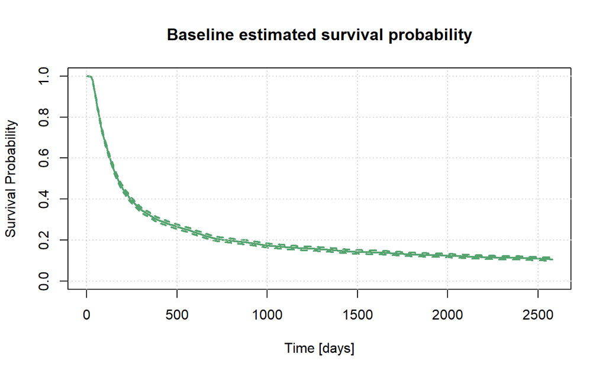

```r
plot(survfit(mod.cox9, data=data),
     col="#55A36F", lwd=2, lty=1,
     xlab='Time [days]', ylab='Survival Probability',
     main='Baseline estimated survival probability')
grid()
```

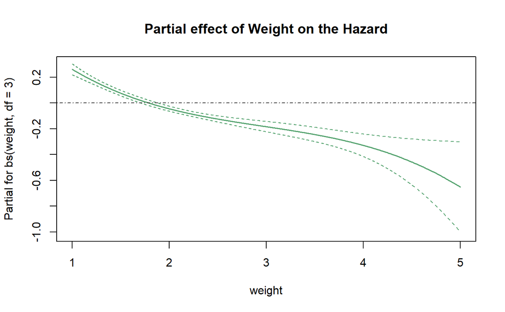

```r
termplot(mod.cox9, term=1, se=TRUE, col.term='#55A36F', col.se='#55A36F', main = 'Partial effect of Weight on the Hazard')
abline(h = 0, lty = 4, col = "#3A3A3A")
```

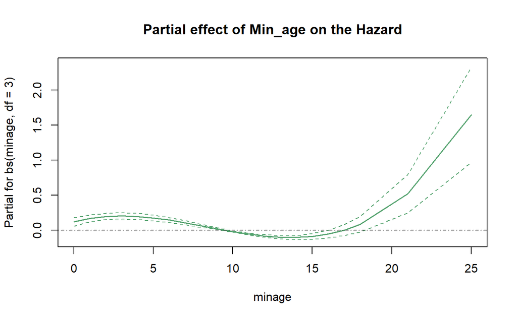

```r
termplot(mod.cox9, term=2, se=TRUE, col.term='#55A36F', col.se='#55A36F', main = 'Partial effect of Min_age on the Hazard')
abline(h = 0, lty = 4, col = "#3A3A3A")
```

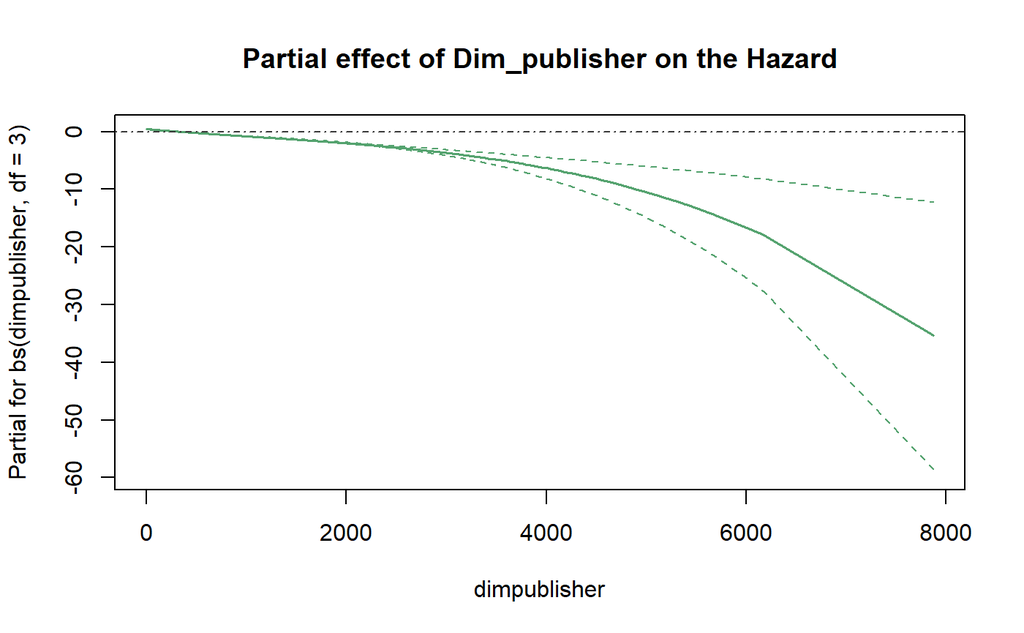

```r
termplot(mod.cox9, term=3, se=TRUE, col.term='#55A36F', col.se='#55A36F', main = 'Partial effect of Dim_publisher on the Hazard')
abline(h = 0, lty = 4, col = "#3A3A3A")
```

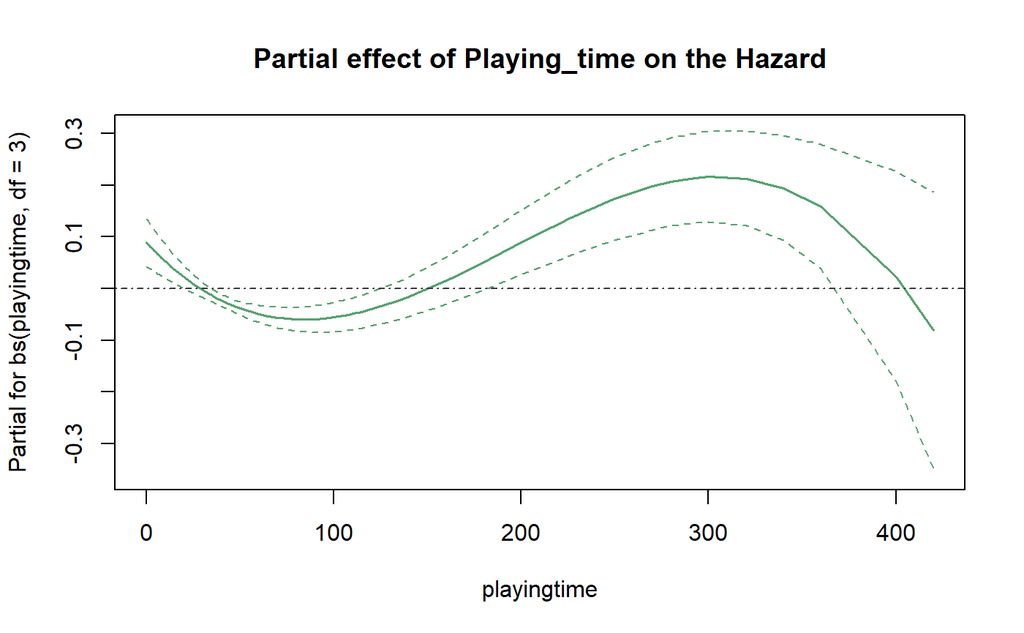

```r
termplot(mod.cox9, term=4, se=TRUE, col.term='#55A36F', col.se='#55A36F', main = 'Partial effect of Playing_time on the Hazard')
abline(h = 0, lty = 4, col = "#3A3A3A")
```

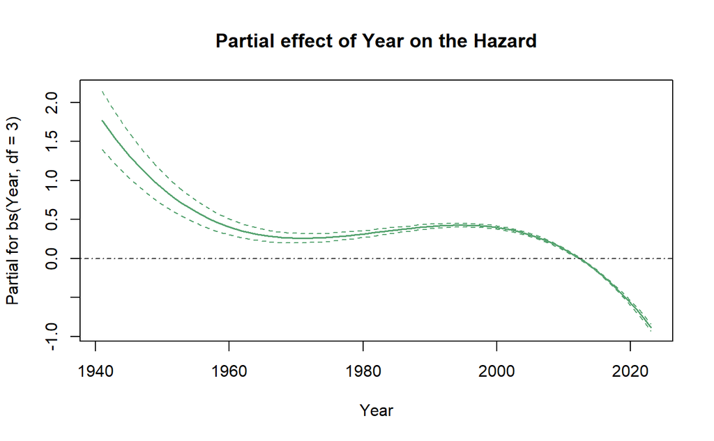

```r
termplot(mod.cox9, term=5, se=TRUE, col.term='#55A36F', col.se='#55A36F', main = 'Partial effect of Year on the Hazard')
abline(h = 0, lty = 4, col = "#3A3A3A")
```

```r
NA
NA
```

### Cox model assumptions and goodness of fit

#### 1) Martingale residuals

```r
##1)Martingale residuals
#a)
plot(predict(mod.cox9), residuals(mod.cox9, type='martingale'),
     xlab='Fitted values', ylab='Martingale residuals', main='Residual Plot', las=1)
# Add a line for residual=0
abline(h=0, col='red')
# Fit a smoother for the points
lines(smooth.spline(predict(mod.cox9), residuals(mod.cox, type='martingale')), col='blue')

#b)
ggcoxdiagnostics(mod.cox9, type = "martingale")
# * A value of martingale residuals near 1 represents individuals that “died too soon”,
# * A large negative value corresponds to individuals that “lived too long”.
```

[output not shown]

#### 2) Deviance residuals

```r
##2)Deviance residuals
ggcoxdiagnostics(mod.cox9, type = "deviance")
# -   Positive values correspond to individuals that "died too soon" compared to expected survival times.
# -   Negative values correspond to individual that "lived too long".
# -   Very large or small values are outliers, which are poorly predicted by the model.
```

[output not shown]

#### 3) Schoenfeld residuals

```r
##3)Schoenfeld residuals
ggcoxdiagnostics(mod.cox9, type = "schoenfeld")
# (. They should be flat, centered about zero.)
# (. They are independent of time.)
#  . A plot that shows a non-random pattern against time is evidence of violation of the PH assumption (the HR for 2 fixed covariate vectors is costant over time).
```

[output not shown]

#### 4) Log-negative-log-KM (for categorical variables)

```r
# ##4)Log-negative-log-KM (ONLY FOR CATEGORICAL VARIABLES!!!!)
# #1)Economic:
# economic.km <- survfit(Surv(time, status) ~ Economic_fact, data = data)
#
# #Plot:
# plot(economic.km, fun='cloglog',
#      col=c("deeppink2","dodgerblue2"), lwd=2, lty=1,
#      ylab="log(-log(Survival Probability))")
# grid()
# legend('topleft', c("Non-Economic", "Economic"),
#        lty=c(1,1), lwd=c(2,2), col=c("deeppink2","dodgerblue2"))
# # If the curves seem to be parallel --> PH assumption seems to be satisfied for this covariate
```

#### 5) Quantitative strategies (test for HP)

```r
##5)Quantitative strategies (test for HP)

# Test for PH using scaled Schoenfeld test for PH
# -   H0: Hazards are proportional
# -   H1: Hazards are NOT proportional

test.ph=cox.zph(mod.cox9)
test.ph
```

```
                            chisq df       p
bs(weight, df = 3)        10.6401  3  0.0138
bs(minage, df = 3)        26.7913  3 6.5e-06
bs(dimpublisher, df = 3)  73.9955  3 5.9e-16
bs(playingtime, df = 3)   10.3968  3  0.0155
bs(Year, df = 3)          96.7356  3 < 2e-16
Negotiation                0.3596  1  0.5487
Political                  5.3864  1  0.0203
Card.Game                  8.4797  1  0.0036
Territory.Building         0.7069  1  0.4005
Children.s.Game            0.3867  1  0.5340
City.Building              1.1974  1  0.2739
Exploration                1.2022  1  0.2729
Farming                    2.6829  1  0.1014
Dice                       1.5059  1  0.2198
Fighting                   4.5582  1  0.0328
Miniatures                 0.3647  1  0.5459
Wargame                   32.6860  1 1.1e-08
Memory                     2.5119  1  0.1130
Industry...Manufacturing   1.1005  1  0.2941
Animals                    0.7122  1  0.3987
Transportation             3.2973  1  0.0694
Action...Dexterity         0.0674  1  0.7951
Spies.Secret.Agents        0.4575  1  0.4988
Book                       0.1859  1  0.6663
Environmental              2.2177  1  0.1364
GLOBAL                   265.8904 35 < 2e-16
```

```r
covariates.nostrata <- names(which(test.ph$table[c(6:25), 3] > 0.05))
covariates.nostrata
```

```
 [1] "Negotiation"              "Territory.Building"       "Children.s.Game"          "City.Building"
 [5] "Exploration"              "Farming"                  "Dice"                     "Miniatures"
 [9] "Memory"                   "Industry...Manufacturing" "Animals"                  "Transportation"
[13] "Action...Dexterity"       "Spies.Secret.Agents"      "Book"                     "Environmental"
```

```r
covaiates.tostrata=setdiff(covariates.toremove.2, covariates.nostrata)

formula.4 <- as.formula(paste("Surv(time, status) ~ bs(weight, df=3) + bs(minage, df=3) + bs(dimpublisher, df=3) + bs(playingtime, df=3) + bs(Year, df=3)  + strata(Fantasy) + strata(Nautical) + strata(Puzzle) + strata(Sports) + ", paste(covariates.nostrata, collapse = " + ")))
mod.cox10 <- coxph(formula.4, data = data)
summary(mod.cox10)
```

```
Call:
coxph(formula = formula.4, data = data)

  n= 19936, number of events= 16715

                                coef  exp(coef)   se(coef)       z Pr(>|z|)
bs(weight, df = 3)1       -5.528e-01  5.753e-01  8.761e-02  -6.309 2.80e-10 ***
bs(weight, df = 3)2       -1.294e-01  8.787e-01  1.407e-01  -0.919 0.357835
bs(weight, df = 3)3       -9.790e-01  3.757e-01  1.840e-01  -5.320 1.04e-07 ***
bs(minage, df = 3)1        4.301e-01  1.537e+00  1.278e-01   3.366 0.000762 ***
bs(minage, df = 3)2       -1.535e+00  2.154e-01  2.282e-01  -6.728 1.72e-11 ***
bs(minage, df = 3)3        1.338e+00  3.811e+00  3.476e-01   3.849 0.000119 ***
bs(dimpublisher, df = 3)1 -3.644e+00  2.614e-02  2.224e-01 -16.390  < 2e-16 ***
bs(dimpublisher, df = 3)2 -2.939e+00  5.294e-02  1.905e+00  -1.542 0.123017
bs(dimpublisher, df = 3)3 -3.037e+01  6.439e-14  1.110e+01  -2.736 0.006224 **
bs(playingtime, df = 3)1  -5.502e-01  5.768e-01  1.087e-01  -5.061 4.17e-07 ***
bs(playingtime, df = 3)2   9.629e-01  2.619e+00  1.531e-01   6.290 3.17e-10 ***
bs(playingtime, df = 3)3  -1.191e-01  8.877e-01  1.460e-01  -0.816 0.414371
bs(Year, df = 3)1         -3.233e+00  3.945e-02  3.282e-01  -9.849  < 2e-16 ***
bs(Year, df = 3)2          4.007e-01  1.493e+00  1.600e-01   2.504 0.012283 *
bs(Year, df = 3)3         -2.670e+00  6.925e-02  2.011e-01 -13.279  < 2e-16 ***
Negotiation                4.253e-02  1.043e+00  4.586e-02   0.927 0.353713
Territory.Building        -2.140e-01  8.074e-01  5.515e-02  -3.879 0.000105 ***
Children.s.Game            1.518e-01  1.164e+00  3.346e-02   4.537 5.69e-06 ***
City.Building             -2.581e-01  7.725e-01  5.684e-02  -4.542 5.58e-06 ***
Exploration               -1.524e-01  8.586e-01  4.159e-02  -3.665 0.000248 ***
Farming                   -2.475e-01  7.808e-01  8.333e-02  -2.970 0.002979 **
Dice                      -8.657e-02  9.171e-01  2.819e-02  -3.071 0.002133 **
Miniatures                -6.455e-02  9.375e-01  3.917e-02  -1.648 0.099371 .
Memory                     1.532e-01  1.166e+00  4.940e-02   3.101 0.001927 **
Industry...Manufacturing  -2.952e-01  7.444e-01  7.401e-02  -3.989 6.63e-05 ***
Animals                   -8.931e-02  9.146e-01  3.336e-02  -2.677 0.007421 **
Transportation            -2.032e-01  8.161e-01  6.014e-02  -3.380 0.000726 ***
Action...Dexterity        -6.470e-02  9.373e-01  3.699e-02  -1.749 0.080294 .
Spies.Secret.Agents       -2.785e-01  7.569e-01  8.339e-02  -3.339 0.000839 ***
Book                       3.080e-01  1.361e+00  8.376e-02   3.678 0.000235 ***
Environmental             -2.640e-01  7.680e-01  9.431e-02  -2.799 0.005129 **
---
Signif. codes:  0 ‘***’ 0.001 ‘**’ 0.01 ‘*’ 0.05 ‘.’ 0.1 ‘ ’ 1

```

[output cut: 22 more lines]

```
Dice                      9.171e-01  1.090e+00 8.678e-01 0.9691652
Miniatures                9.375e-01  1.067e+00 8.682e-01 1.0122987
Memory                    1.166e+00  8.580e-01 1.058e+00 1.2840291
Industry...Manufacturing  7.444e-01  1.343e+00 6.439e-01 0.8605492
Animals                   9.146e-01  1.093e+00 8.567e-01 0.9763540
Transportation            8.161e-01  1.225e+00 7.253e-01 0.9181731
Action...Dexterity        9.373e-01  1.067e+00 8.718e-01 1.0078356
Spies.Secret.Agents       7.569e-01  1.321e+00 6.428e-01 0.8913341
Book                      1.361e+00  7.349e-01 1.155e+00 1.6035222
Environmental             7.680e-01  1.302e+00 6.384e-01 0.9239360

Concordance= 0.653  (se = 0.003 )
Likelihood ratio test= 6998  on 31 df,   p=<2e-16
Wald test            = 5315  on 31 df,   p=<2e-16
Score (logrank) test = 5991  on 31 df,   p=<2e-16
```

```r
test.ph=cox.zph(mod.cox10)
test.ph
```

```
                            chisq df       p
bs(weight, df = 3)        10.6381  3   0.014
bs(minage, df = 3)        22.3488  3 5.5e-05
bs(dimpublisher, df = 3)  70.4760  3 3.4e-15
bs(playingtime, df = 3)    7.9648  3   0.047
bs(Year, df = 3)          88.6330  3 < 2e-16
Negotiation                0.3570  1   0.550
Territory.Building         0.4742  1   0.491
Children.s.Game            0.1220  1   0.727
City.Building              1.5813  1   0.209
Exploration                0.8789  1   0.348
Farming                    2.3466  1   0.126
Dice                       1.2740  1   0.259
Miniatures                 0.4729  1   0.492
Memory                     3.2620  1   0.071
Industry...Manufacturing   1.3095  1   0.252
Animals                    0.5480  1   0.459
Transportation             2.9935  1   0.084
Action...Dexterity         0.0891  1   0.765
Spies.Secret.Agents        0.4647  1   0.495
Book                       0.2909  1   0.590
Environmental              2.1637  1   0.141
GLOBAL                   230.7702 31 < 2e-16
```

```r
#Plot (scaled Schoenfeld residuals):
# #a)
# par(mfrow=c(2,2))
# for(i in 1:4){
#   plot(test.ph[i])
#   abline(h=0, col='red')
# }
#
# #b)
# ggcoxdiagnostics(mod.cox, type = "scaledsch")
```